# STAT167 Lab #2 - Spring 2021

Deisy Diaz

ddiaz022@ucr.edu

2021/4/9

**Acknowledgments**: Part of this R Markdown template is adapted from David Dalpiaz (UIUC) and Cosma Shalizi (CMU).

# **Discussion week 2 instructions**

This week, you will first learn a bit more about R Markdown.

- First, download the `rmd` file from iLearn. It gives you an option to “open” or “save”. Make sure that you **save** the file to the `Desktop`, `Downloads`, `Documents`, or any other location where you have access to.
- Open this `rmd` file in RStudio and click `Knit -> Knit to HTML` to render it to HTML format. (If you have `LaTex` installed on your computer, you can also render it to PDF format).
- Read this `rmd` file and the rendered `html` file side-by-side, to see how this document was generated!
- Be sure to play with this document! Change it. Break it. Fix it. The best way to learn R Markdown (or really almost anything) is to try, fail, then find out what you did wrong.

Next, you will review some visualization example figures from this week’s lectures.

- Read over the code and the output. If you have any questions about certain functions or parameters, it is the time to ask!
- There are some exercises through out this document. Replace **INSERT_YOUR_ANSWER** with your own answers. Knit the file to HTML, and check your results.

**Please comment your R code thoroughly, and follow the R coding style guideline (https://google.github.io/styleguide/Rguide.xml). Partial credit will be deducted for insufficient commenting or poor coding styles.**

**Lab submission guideline**

- After you completed all exercises, save your file to `FirstnameLastname-SID-lab2.rmd` and save the rendered html/pdf file to `FirstnameLastname-SID-lab2.html` or `FirstnameLastname-SID-lab2.pdf`.
- Submit **BOTH your source `rmd` file and the knitted `html` or `pdf` file** to **GradeScope**. Do NOT create a zip file. You can submit multiple times, you last submission will be graded.

# RMarkdown

## More Formatting in R Markdown

### Paragraph Breaks and Forced Line Breaks

To insert a break between paragraphs, include a single completely blank line.

To force a line break, put *two* blank  
spaces at the end of a line.

### Computer Type

Text to be printed in a fixed-width font, without further interpretation, goes in paired left-single-quotes, a.k.a. “back-ticks”, without line breaks in your typing. (Thus `R` vs. R.)

### Quotations

Set-off quoted paragraphs are indicated by an initial `>`:

> In fact, all epistemological value of the theory of probability is based on this: that large-scale random phenomena in their collective action create strict, nonrandom regularity. [Gnedenko and Kolmogorov, *Limit Distributions for Sums of Independent Random Variables*, p. 1]

### More about bullet points

- This is a list marked where items are marked with bullet points.
- Each item in the list should start with a `*` (asterisk) character, or a `-` (single dash) character, or a `+` (plus sign) character. You can use them interchangeably, though it is **NOT** a good practice.
- Each item should also be on a new line.
  - Indent lines and begin them with `*` or `+` or `-` for sub-bullets.
  - Usually indentation by two spaces is sufficient for sub-bullets.
  - Sub-sub-bullet aren’t really a thing in R Markdown.

## Math in R Markdown

Since this is a statistics class, you need to be able to write out mathematical expressions, often long series of them. R Markdown gives you the syntax to render complex mathematical formulas and derivations, and have them displayed very nicely. Like code, the math can either be inline or set off (**displays**).

Inline math is marked off with a pair of dollar signs (`$`), as $\pi r^2$ or $e^{i\pi}$.

Mathematical displays are marked off with a pair of double dollar signs (`$$`) or a pair of `\[` and `\]`, as in

$$e^{i \pi} = -1$$

$$e^{i \pi} = -1$$

For more information about the elements of Math mode, please refer to this [excellent tutorial from Dr. Shalizi](http://www.stat.cmu.edu/~cshalizi/rmarkdown/#math-in-r-markdown).

# **Lecture Review**

## Plot single data set

```r
# generate random normals
set.seed(167) # feel free to change 167 to your lucky number
x <- rnorm(100) # use <- for assignment instead of =
```

Note that you can modify chunk options `fig.height` and `fig.width` to change the size of plots from a particular chunk.

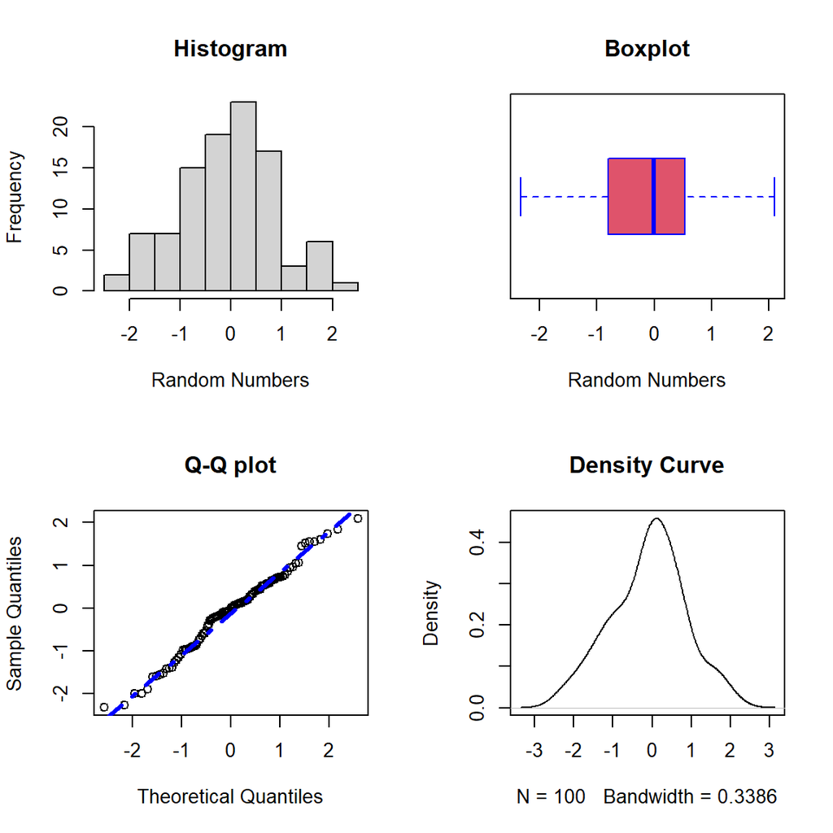

```r
par(mfrow=c(2,2)) # 2-by-2 layout

# subfigure #1
hist(x, xlab="Random Numbers", main="Histogram")

# subfigure #2
boxplot(x, horizontal=T, col=2, border="blue", xlab="Random Numbers", main="Boxplot")

# subfigure #3
qqnorm(x, main="Q-Q plot")
qqline(x,lwd=3, lty=4, col="blue")

# subfigure #4
plot(density(x), main="Density Curve")
```

## Plot a theoretical standard normal curve

```r
z <- seq(-4, 4, length=100)
z
```

```
##   [1] -4.00000000 -3.91919192 -3.83838384 -3.75757576 -3.67676768 -3.59595960
##   [7] -3.51515152 -3.43434343 -3.35353535 -3.27272727 -3.19191919 -3.11111111
##  [13] -3.03030303 -2.94949495 -2.86868687 -2.78787879 -2.70707071 -2.62626263
##  [19] -2.54545455 -2.46464646 -2.38383838 -2.30303030 -2.22222222 -2.14141414
##  [25] -2.06060606 -1.97979798 -1.89898990 -1.81818182 -1.73737374 -1.65656566
##  [31] -1.57575758 -1.49494949 -1.41414141 -1.33333333 -1.25252525 -1.17171717
##  [37] -1.09090909 -1.01010101 -0.92929293 -0.84848485 -0.76767677 -0.68686869
##  [43] -0.60606061 -0.52525253 -0.44444444 -0.36363636 -0.28282828 -0.20202020
##  [49] -0.12121212 -0.04040404  0.04040404  0.12121212  0.20202020  0.28282828
##  [55]  0.36363636  0.44444444  0.52525253  0.60606061  0.68686869  0.76767677
##  [61]  0.84848485  0.92929293  1.01010101  1.09090909  1.17171717  1.25252525
##  [67]  1.33333333  1.41414141  1.49494949  1.57575758  1.65656566  1.73737374
##  [73]  1.81818182  1.89898990  1.97979798  2.06060606  2.14141414  2.22222222
##  [79]  2.30303030  2.38383838  2.46464646  2.54545455  2.62626263  2.70707071
##  [85]  2.78787879  2.86868687  2.94949495  3.03030303  3.11111111  3.19191919
##  [91]  3.27272727  3.35353535  3.43434343  3.51515152  3.59595960  3.67676768
##  [97]  3.75757576  3.83838384  3.91919192  4.00000000
```

```r
prob.z <- dnorm(z) # calculate the standard normal densities
prob.z
```

```
##   [1] 0.0001338302 0.0001842953 0.0002521381 0.0003427099 0.0004627846
##   [6] 0.0006208623 0.0008275148 0.0010957722 0.0014415473 0.0018840898
##  [11] 0.0024464615 0.0031560163 0.0040448664 0.0051503080 0.0065151783
##  [16] 0.0081881065 0.0102236211 0.0126820683 0.0156292995 0.0191360817
##  [21] 0.0232771927 0.0281301641 0.0337736510 0.0402854146 0.0477399263
##  [26] 0.0562056185 0.0657418315 0.0763955298 0.0881978860 0.1011608535
##  [31] 0.1152738702 0.1305008512 0.1467776382 0.1640100747 0.1820728700
##  [36] 0.2008093962 0.2200325354 0.2395266587 0.2590507715 0.2783428081
##  [41] 0.2971250031 0.3151102096 0.3320089800 0.3475371752 0.3614238299
##  [46] 0.3734189738 0.3833010942 0.3908839312 0.3960223134 0.3986167793
##  [51] 0.3986167793 0.3960223134 0.3908839312 0.3833010942 0.3734189738
##  [56] 0.3614238299 0.3475371752 0.3320089800 0.3151102096 0.2971250031
##  [61] 0.2783428081 0.2590507715 0.2395266587 0.2200325354 0.2008093962
##  [66] 0.1820728700 0.1640100747 0.1467776382 0.1305008512 0.1152738702
##  [71] 0.1011608535 0.0881978860 0.0763955298 0.0657418315 0.0562056185
##  [76] 0.0477399263 0.0402854146 0.0337736510 0.0281301641 0.0232771927
##  [81] 0.0191360817 0.0156292995 0.0126820683 0.0102236211 0.0081881065
##  [86] 0.0065151783 0.0051503080 0.0040448664 0.0031560163 0.0024464615
##  [91] 0.0018840898 0.0014415473 0.0010957722 0.0008275148 0.0006208623
##  [96] 0.0004627846 0.0003427099 0.0002521381 0.0001842953 0.0001338302
```

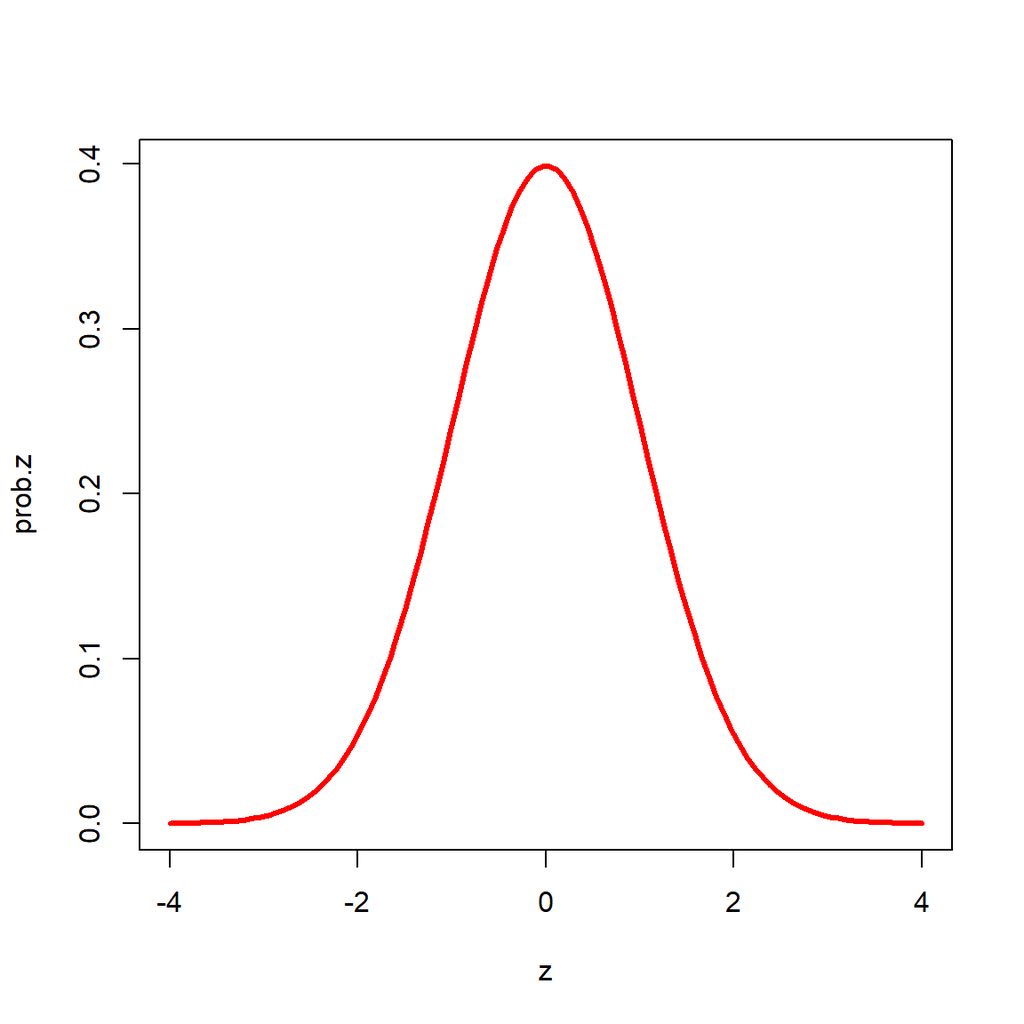

```r
plot(z, prob.z, lwd=3, col="red", type="l") # draw the theoretical normal curve
```

### **Exercise #1**

Plot the probability density function of $N(\mu=1.2, \sigma=0.8)$.

**ANSWERS**

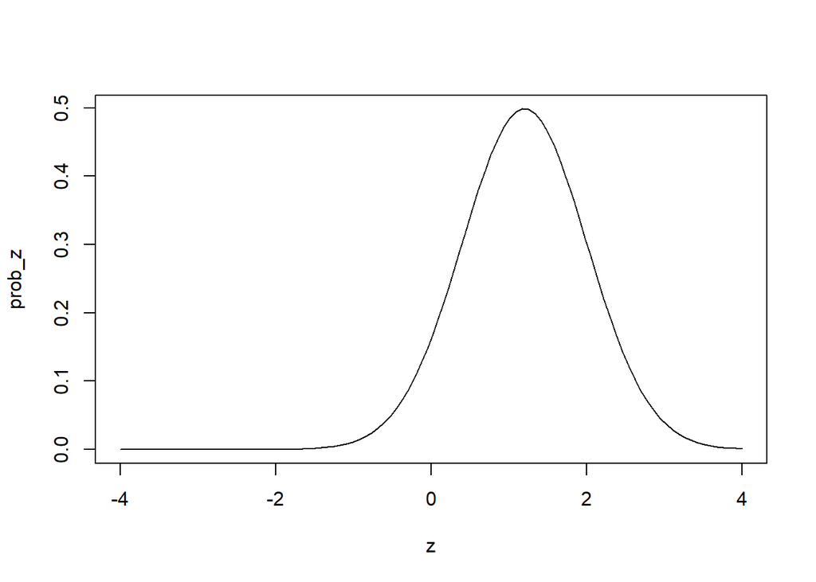

```r
# INSERT_YOUR_ANSWER
prob_z <- dnorm(z, mean = 1.2, 0.8) #get values of the dnorm from -4 to 4 with mean 1.2 and sd = 0.8
plot(z,prob_z, type = "l") # plot density function
```

### **Exercise #2**

Can you draw these two normal curves, $N(\mu=0, \sigma=1)$ and $N(\mu=1.2, \sigma=0.8)$, in the same plot?

**ANSWERS**

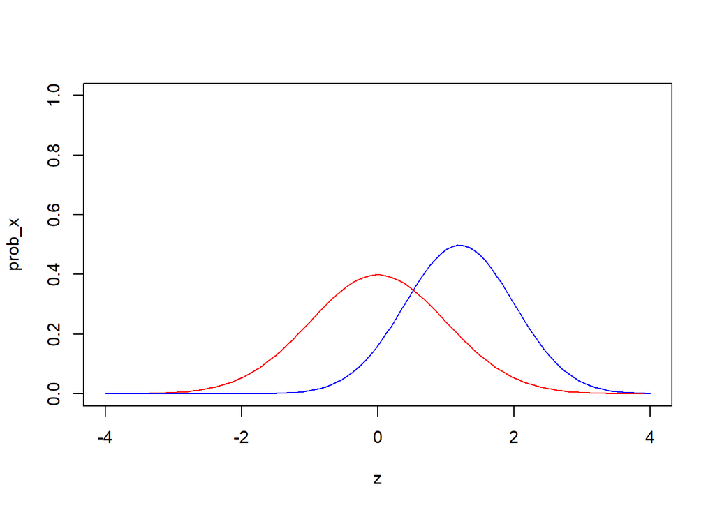

```r
# INSERT_YOUR_ANSWER
prob_x <- dnorm(z, mean = 0, 1) # get dnorm values for mean = 0 and sd = 1
prob_y <- dnorm(z, mean = 1.2, 0.8) # get dnorm values for mean = 1.2 and sd = 0.8
plot(z, prob_x, col = "red", ylim = c(0,1), type = "l") # plot the first density curve color red
lines(z, prob_y, col = "blue") # plot the second density curve color blue
```

## Scatter plot of two data sets

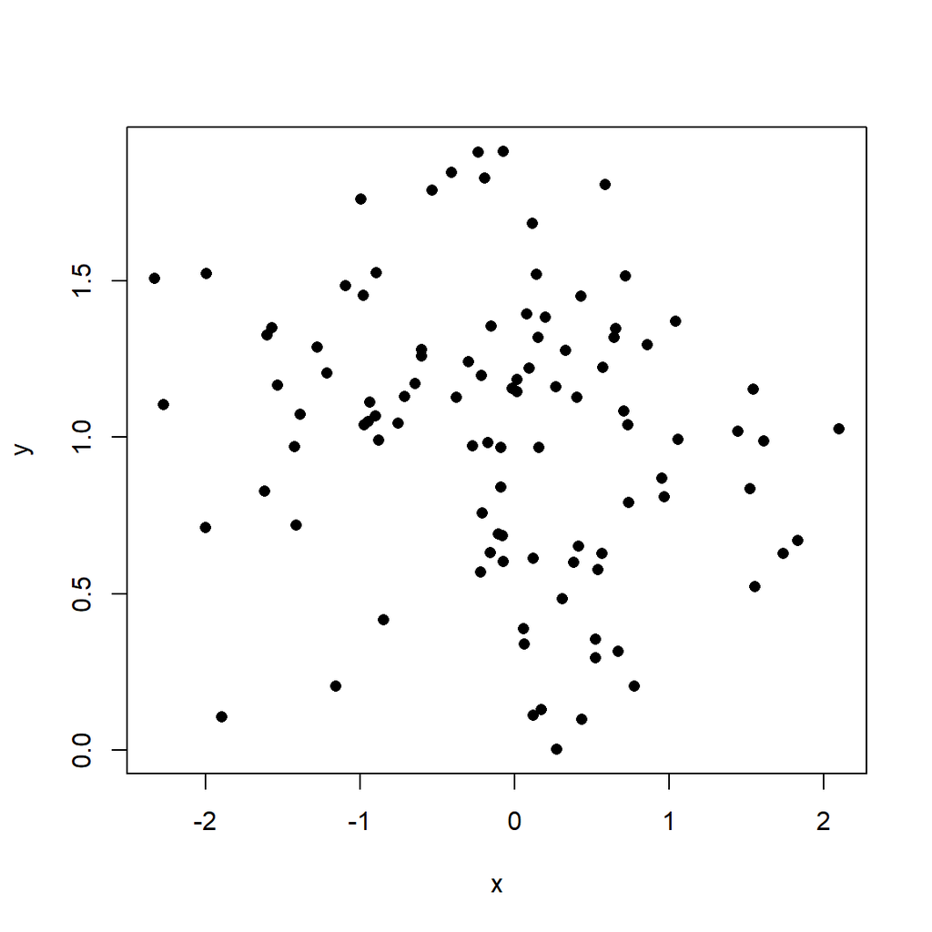

```r
y <- rnorm(n=100, mean=1, sd=.5)
plot(x,y, pch=16)
```

## Annotate your scatter plot

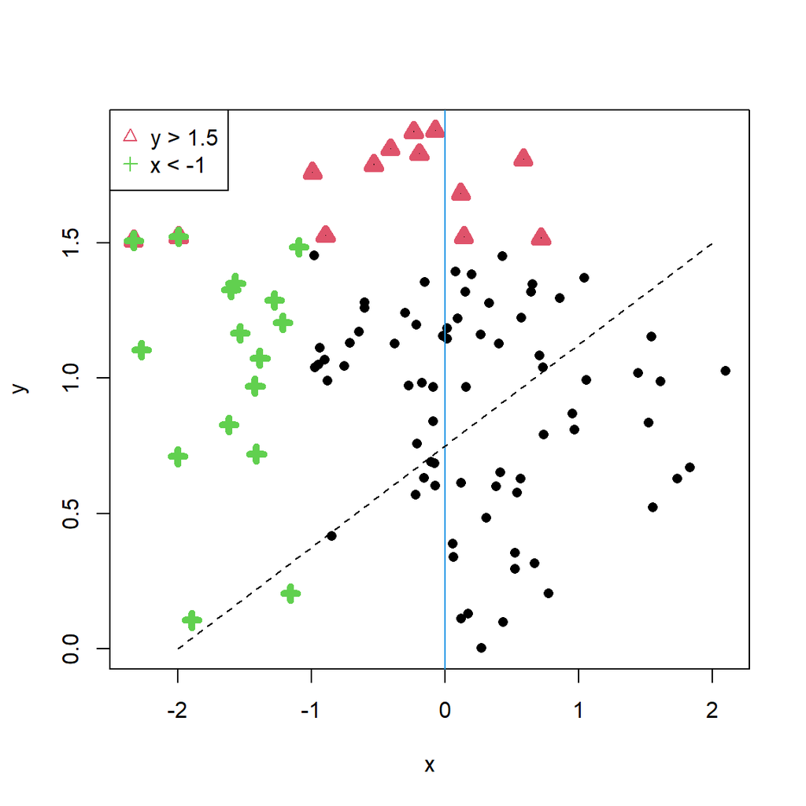

```r
plot(x, y, pch=16)
points(x[y > 1.5], y[y > 1.5], col=2, pch=2, lwd=5)
points(x[x < -1], y[x < -1], col=3, pch=3, lwd=5) # do not write as x[x<-1]
legend("topleft", legend=c("y > 1.5","x < -1"), col=c(2,3), pch=c(2,3))
abline(v=0, col=4)
lines(x=c(-2,2), y=c(0,1.5), lty=2)
```

### **Exercise #3**

Annotate your own scatter plot:

- select points with x < -2 (leave space on both sides of `<`), color them in red and change their point symbol (to anything other than solid points)
- add a legend at the right bottom of the figure indicating those red color points are “likely outliers”
- add a blue dashed horizontal line at $\bar{y}$

**ANSWERS**

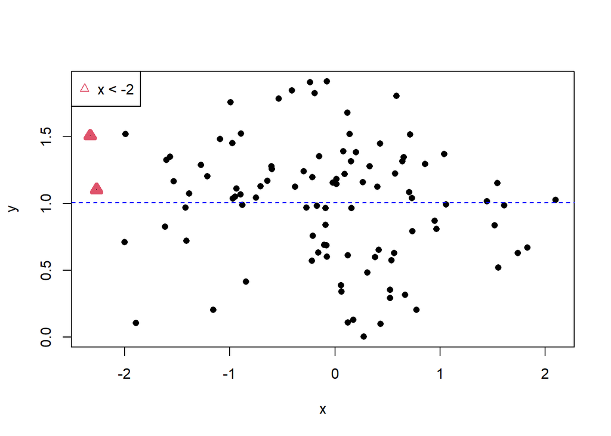

```r
plot(x,y, pch=16)
y.bar <- mean(y) # it does not necessarily equal to 1.0
# INSERT_YOUR_ANSWER
points(x[x < -2], y[x < -2], col=2, pch=2, lwd=5) # plot x and y values of which x < -2, red triangles
abline(h = y.bar, lty = 2, col = "blue") # draw a blue dashed line at y.bar
legend("topleft", legend="x < -2", col=2, pch=2) # make a legend that says red triangles are for values with x < -2
```